# Ford GoBike Trip Data Analysis

## by Azadeh Iranmehr

## Investigation Overview

> In this presentation, my goal is to conduct an explanatory data analysis on Ford GoBike Trip dataset to better understand user's behaviours , characteristics and specifications . We can find impacts of weather, gender, age, hour of the day , days of the week, months and other items on the number of trips or trip duration in this bike system.

## Dataset Overview

> The dataset, 2017-fordgobike-tripdata.csv, is downloaded from following link and licensed by Ford GoBike. This dataset includes 519,700 trips with 15 features such as locations, time, and user attributes for bike_sharing system. Bike-sharing is gaining popularity, since it provides a convenient solution for short distance transportation, especially where the typical public transportation systems could not cover thoroughly. Riders can pick up a bike from one station and drop off at any other in the network. In return the system can keep on operating with income from: 1. rider membership fee(subscribers), or 2. one time pay-to-ride rental fee(customers). This document explores a this dataset containing information about individual rides of Ford GoBike sharing system covering in 2017. Dataset address is : https://s3.amazonaws.com/fordgobike-data/2017-fordgobike-tripdata.csv

## 1-Distribution of user type and gender

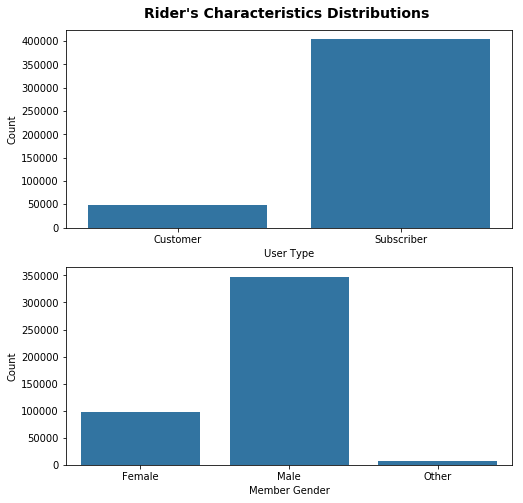

```python
#  distributions of user type and gender
fig, ax = plt.subplots(nrows=2, figsize = [8,8])
default_color = sb.color_palette()[0]
sb.countplot(data = df_clean, x = 'user_type', color = default_color, ax = ax[0])
sb.countplot(data = df_clean, x = 'member_gender', color = default_color, ax = ax[1])
ax[0].set_xlabel('User Type')
ax[0].set_ylabel('Count')
ax[1].set_xlabel('Member Gender')
ax[1].set_ylabel('Count')
ax[0].set_title('Rider\'s Characteristics Distributions ',  y=1.03,fontsize=14, fontweight='semibold');
```

Most of the users are Subscriber than Customer. Most of the users are Male than Female . Male bike rides is 3 times more than female

## 2- Distribution of time of the trip

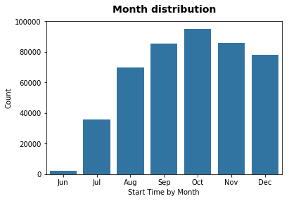

```python
base_color = sb.color_palette()[0]
sb.countplot(data=df_clean, x='start_month_char', color=base_color)
plt.xlabel('Start Time by Month')
plt.ylabel('Count')
plt.title('Month distribution',  y=1.03,fontsize=14, fontweight='semibold');
```

October has the most and june has the least number of trip count. Number of trips on June is extremly low . That should have further investigation for this month. It is obvious that during hot weather less users use this bike system and during good weather like in October or November more user use this system.

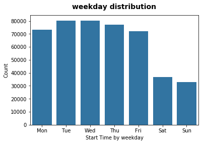

```python
base_color = sb.color_palette()[0]
sb.countplot(data=df_clean, x='start_weekday_char', color=base_color)
plt.xlabel('Start Time by weekday')
plt.ylabel('Count')
plt.title('weekday distribution',  y=1.03,fontsize=14, fontweight='semibold');
```

Most trips took place during week days. And less trips are on weekends.

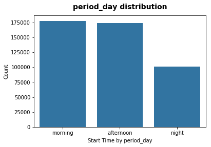

```python
base_color = sb.color_palette()[0]
sb.countplot(data=df_clean, x='period_day', color=base_color)
plt.xlabel('Start Time by period_day')
plt.ylabel('Count')
plt.title('period_day distribution',  y=1.03,fontsize=14, fontweight='semibold');
```

Number of trip at night is less than morning and afternoon.

## 3- compare age of two user types

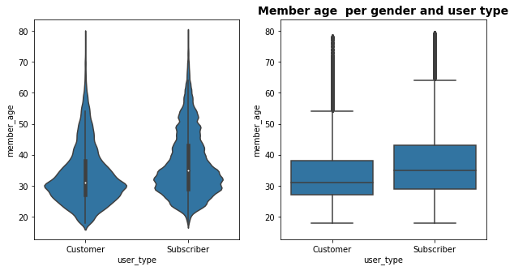

```python
plt.figure(figsize = [10, 5])
base_color = sb.color_palette()[0]

# left plot: violin plot
plt.subplot(1, 2, 1)
ax1 = sb.violinplot(data = df_clean, x = 'user_type', y = 'member_age', color = base_color)

# right plot: box plot
plt.subplot(1, 2, 2)
g=sb.boxplot(data = df_clean, x = 'user_type', y = 'member_age', color = base_color)
plt.ylim(ax1.get_ylim()) # set y-axis limits to be same as left plot
plt.title('Member age  per gender and user type', fontsize=14, fontweight='semibold');
```

from violon plot and box plot above, we can see that subscribers have more median age than customers.

## 4-Number of trips taken by different user group

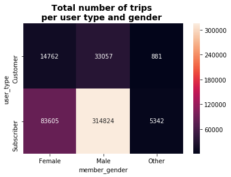

```python
ct_counts = df_clean.groupby(['member_gender', 'user_type']).size()
ct_counts = ct_counts.reset_index(name = 'count')
ct_counts = ct_counts.pivot(index = 'user_type', columns = 'member_gender', values = 'count')
sb.heatmap(ct_counts, annot = True, fmt = 'd')
plt.title('Total number of trips \nper user type and gender ', y=1.03, fontsize=14, fontweight='semibold');
```

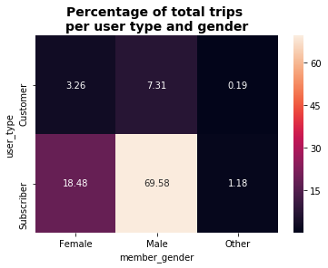

```python
sb.heatmap(trips, annot=True, fmt=".2f");
plt.title('Percentage of total trips \nper user type and gender', y=1.03, fontsize=14, fontweight='semibold');
```

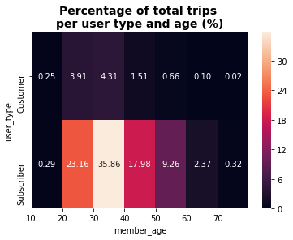

```python
df0 = df_clean.groupby([bin_idxs, 'user_type']).size()
df0 = df0.reset_index(name='trip_count')
df0 = df0.pivot('user_type','member_age', 'trip_count')/total*100
sb.heatmap(df0, annot=True, fmt=".2f");
plt.xticks([0,1,2,3,4,5,6],['10','20','30','40','50','60','70'])
plt.title('Percentage of total trips \nper user type and age (%)', y=1.03, fontsize=14, fontweight='semibold');
```

Subscribers group with rang age of 30-40 years old has the greatest percentage of the total trips(35.86%) and custumers group with rang age of 70-80 years old has the least percentage of the total trips(0.02) .

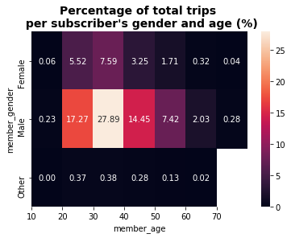

```python
df1 = df_clean.query('user_type == "Subscriber"').groupby([bin_idxs, 'member_gender']).size()
df1 = df1.reset_index(name='trip_count')
df1 = df1.pivot('member_gender', 'member_age', 'trip_count')/total*100

sb.heatmap(df1, annot=True, fmt=".2f");
plt.xticks([0,1,2,3,4,5,6],['10','20','30','40','50','60','70'])
plt.title('Percentage of total trips \n per subscriber\'s gender and age (%)' , y=1.03, fontsize=14, fontweight='semibold');
```

Male riders with the age rang 30-40 years has the greatest percentage of total trip.

By plotting the percentage of trips taken by different user groups with heatmaps, we can get a feel for the user behavior across gender, age, and their subscription status.

## 5-Trip duration per user type and day of week

[figure not shown]

```python
# create clustered box plots to compare trip duration by day of week and user type

df_clean['log_duration_sec'] = np.log10(df_clean['duration_sec'])
plt.figure(figsize=(10,8))
sb.boxplot(data = df_clean, x = 'start_weekday_char', y = 'log_duration_sec', hue = 'user_type')
plt.legend(loc = 6, bbox_to_anchor = (1.0, 0.5))

xticks = [0, 1, 2, 3, 4, 5, 6]
xlabels = ['Monday','Tuesday','Wednesday','Thursday','Friday','Saturday','Sunday']
plt.xticks(xticks, xlabels, rotation = 90)

ylabels = [1, 3, 10, 30, 100, 300, 1000, 3000]
yticks = np.log10(ylabels)
plt.yticks(yticks, ylabels)
plt.xlabel('Day of the Week')
plt.ylabel('Duration (Minutes)')
plt.title('Trip Duration by User Type and Day of the Week', y=1.03, fontsize=14, fontweight='semibold');
```

The trip duration for Customers is greater than Subscribers and during weekends is greater than weekdays.

## 6-Trip duration per Gender and user type

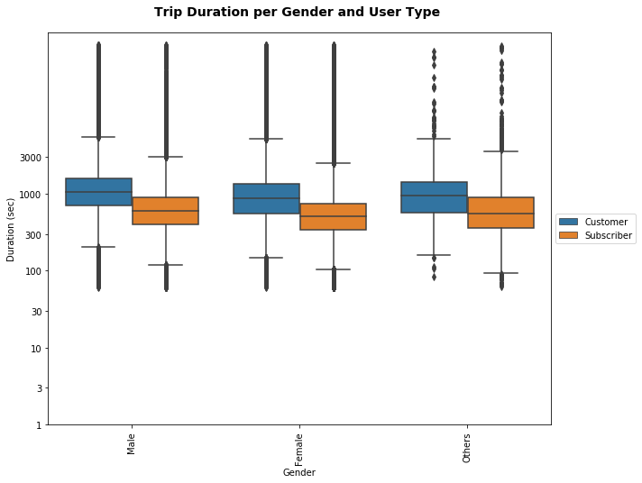

```python
# create clustered box plots to compare trip duration per gender and user type

df_clean['log_duration_sec'] = np.log10(df_clean['duration_sec'])
plt.figure(figsize=(10,8))
sb.boxplot(data = df_clean, x = 'member_gender', y = 'log_duration_sec', hue = 'user_type')
plt.legend(loc = 6, bbox_to_anchor = (1.0, 0.5))

xticks = [0, 1, 2]
xlabels = ['Male','Female','Others']
plt.xticks(xticks, xlabels, rotation = 90)

ylabels = [1, 3, 10, 30, 100, 300, 1000, 3000]
yticks = np.log10(ylabels)
plt.yticks(yticks, ylabels)
plt.xlabel('Gender')
plt.ylabel('Duration (sec)')
plt.title('Trip Duration per Gender and User Type ',y=1.03, fontsize=14, fontweight='semibold');
```

## 7-Ages of users in different user's group

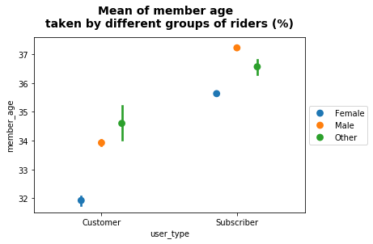

```python
# use pointplot functions for 2 categorical variable and one numerical variable in a clustered fashion
ax = sb.pointplot(data = df_clean, x = 'user_type', y = 'member_age', hue = 'member_gender',
                  dodge = 0.3, linestyles = "")
plt.title('Mean of member age  \ntaken by different groups of riders (%)', y=1.03, fontsize=14, fontweight='semibold');
plt.legend(loc = 6, bbox_to_anchor = (1.0, 0.5));
```

Female customers have least age, Male subscribers have greatest age. Amount of uncertainty for Other group greater than male or female .

## 8-Hourly trip count per gender and user type

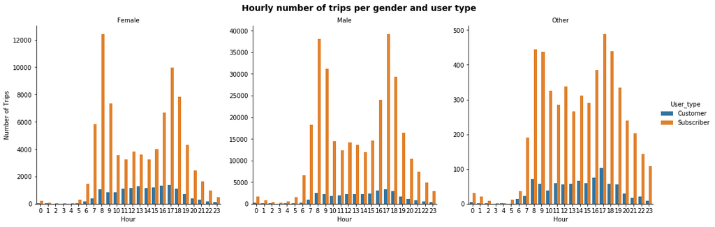

```python
# hourly usege of the bike sharing system per user type and gender

g = sb.catplot(data=df_clean, x='start_hour', col="member_gender", hue='user_type', kind='count', sharey = False)
g.set_axis_labels("Hour", "Number of Trips")
g._legend.set_title('User_type')
g.set_titles("{col_name}")
g.fig.suptitle('Hourly number of trips per gender and user type', y=1.03, fontsize=14, fontweight='semibold');
```

Customers ride bikes mainly between 8:00 am to 19:00 ; subscribers on the other side bike between around 8:00-9:00 to 17:00 - 18:00 in their commute to work.The peak number of trips are at 8:00 or 9:00 in the morning and at 17:00 or 18:00 in the afternoon. As we saw in previous plots ,in this plot we can also see that subscribers have much more trips than customers. In this plot we can also see that number of trip for male users is much greater than female and for female is much greater than other.

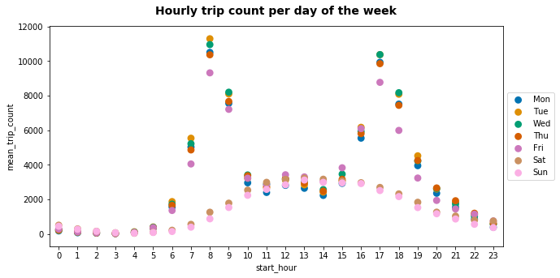

```python
# create clustered point plots to compare mean trip count and mean trip duration by day of week and user type

fig = plt.figure(figsize=(10,5))

df1 = df_clean.groupby(['start_weekday_char','start_hour']).size()
df1 = df1.reset_index(name='mean_trip_count')


sb.pointplot(data = df1, x = 'start_hour', y = 'mean_trip_count', hue = 'start_weekday_char', palette = 'colorblind', linestyles = '')
plt.title('Hourly trip count per day of the week', y=1.03, fontsize=14, fontweight='semibold' )
plt.legend(loc = 6, bbox_to_anchor = (1.0, 0.5));
```

Most of the riders in this system start their trip at 8:00 and 17:00 during weekdays.Most tips usually took place between 7:00 to 17:00. Less trip took place during night. During weekend most of the trips start at noon